# TalkingData: Adtracking Fraud Detection em R

## Introdução

Esse é o primeiro projeto realizado para a finalização do curso Big Data Analytics com R e Microsoft Azure Machine Learning da Data Science Academy.

A proposta e o dataset para este projeto foram retirados de um campeonato realizado no kaggle pela companhia Talking Data.

Nessa competição, o objetivo era construir um algoritmo que previsse se determinado usuário iria baixar ou não um aplicativo após clicar em uma propaganda .

## Processamento de Dados

A base de dados completa oferecida pela empresa contém mais de 200 milhões de cliques registrados, porém para maior agilidade na produção, foi utilizada uma amostra com 100 mil observações para a construção desse projeto.

Com a amostra carregada, ela será dividida entre treino e teste para dar prosseguimento as análises.

```r
set.seed(6878)

df <- fread('train_sample.csv')
kable(head(df))
```

| ip | app | device | os | channel | click_time | attributed_time | is_attributed |
| --- | --- | --- | --- | --- | --- | --- | --- |
| 87540 | 12 | 1 | 13 | 497 | 2017-11-07 09:30:38 | NA | 0 |
| 105560 | 25 | 1 | 17 | 259 | 2017-11-07 13:40:27 | NA | 0 |
| 101424 | 12 | 1 | 19 | 212 | 2017-11-07 18:05:24 | NA | 0 |
| 94584 | 13 | 1 | 13 | 477 | 2017-11-07 04:58:08 | NA | 0 |
| 68413 | 12 | 1 | 1 | 178 | 2017-11-09 09:00:09 | NA | 0 |
| 93663 | 3 | 1 | 17 | 115 | 2017-11-09 01:22:13 | NA | 0 |

```r
#Cria Indice Para Divisao (Treino 80% dos dados)
treino <- createDataPartition(df$is_attributed, p = .8, list = FALSE)

data_treino <- df[treino,]
data_teste <- df[-treino,]
```

## Análise Exploratória dos Dados

Com os dados em mãos, antes de realizar algum tipo de manipulação neles, é importante entendê-los e explora-los.

```
## Classes 'data.table' and 'data.frame':   80000 obs. of  8 variables:
##  $ ip             : int  87540 105560 101424 94584 93663 17059 121505 143636 73839 36150 ...
##  $ app            : int  12 25 12 13 3 1 9 3 3 2 ...
##  $ device         : int  1 1 1 1 1 1 1 1 1 1 ...
##  $ os             : int  13 17 19 13 17 17 25 19 22 13 ...
##  $ channel        : int  497 259 212 477 115 135 442 135 489 205 ...
##  $ click_time     : POSIXct, format: "2017-11-07 09:30:38" "2017-11-07 13:40:27" ...
##  $ attributed_time: POSIXct, format: NA NA ...
##  $ is_attributed  : int  0 0 0 0 0 0 0 0 0 0 ...
##  - attr(*, ".internal.selfref")=<externalptr>
```

Com esse comando identificamos que em nossa base existem dados númericos (int) e do tipo POSIXct (data com horas, minutos e segundos); porém com a leitura dos dicionários de dados disponível no kaggle , nota-se que `ip`, `app` , `device`, `os` e `channel` são códigos de indentificação.

A primeira análise realizada é a da relação entre esses códigos de identificação com a variável `is_attributed`, nossa variável target.

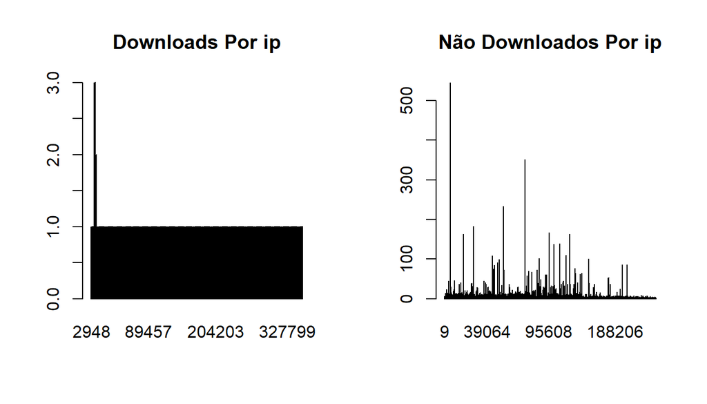

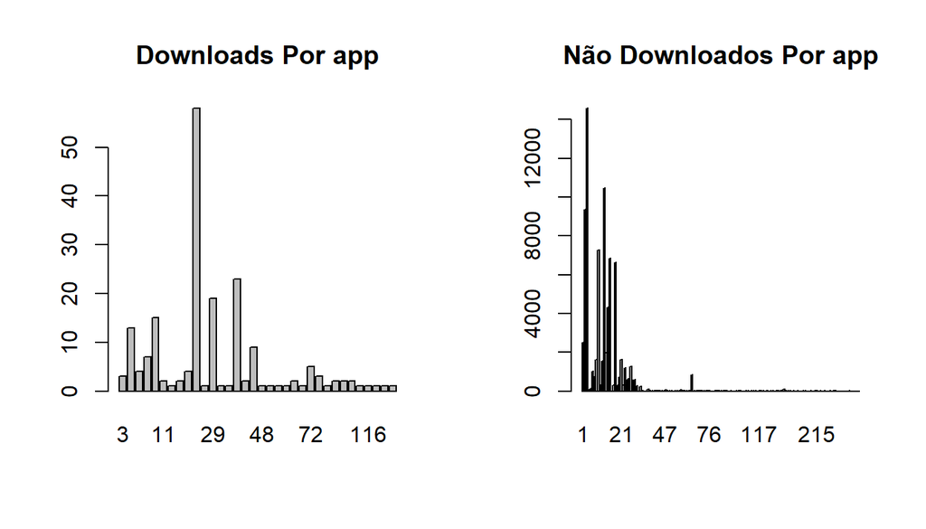

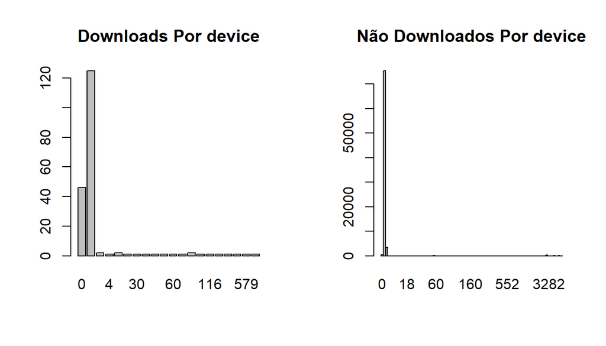

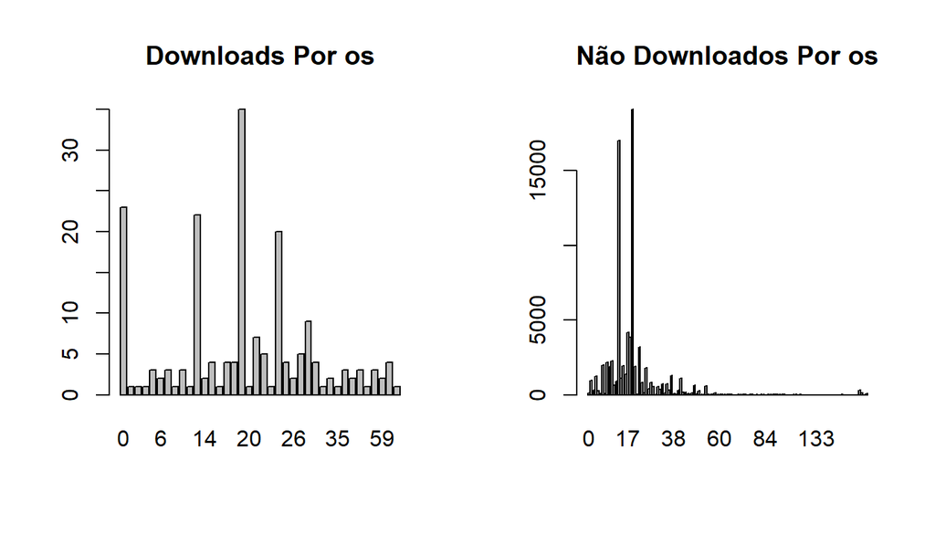

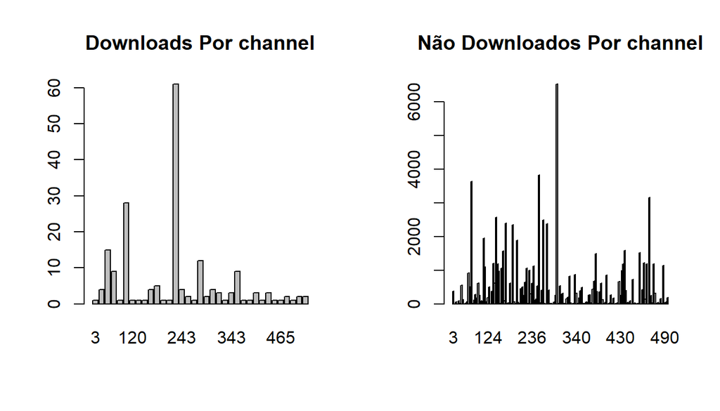

```r
#Define uma função para gerar um gráfico para cada variável de
#forma automática

fucBarPlot <- function(x){
  par(mfrow = c(1,2))
  barplot(table(base::subset(data_treino, is_attributed == 1, select = x)), main = paste('Downloads Por',x))
  barplot(table(base::subset(data_treino, is_attributed == 0, select = x)), main = paste('Não Downloados Por',x))
}

#aplica a função as variáveis escolhidas

for (element in colnames(data_treino)[1:5]) {
  fucBarPlot(element)
}
```

Através dos gráficos, é possível identificar quem em média existe um download por IP, e que existem alguns outros que geram muito mais cliques sem downloads do que a média, podendo evidenciar o uso de bots ou programas fraudulentos.

Também é notável que a variável device é a que mais apresenta recorrência de downloads por uma categoria específica.

Com essa análise das variáveis categorias feitas, pode-se partir para uma análise das variáveis do tipo date, através de séries temporais.

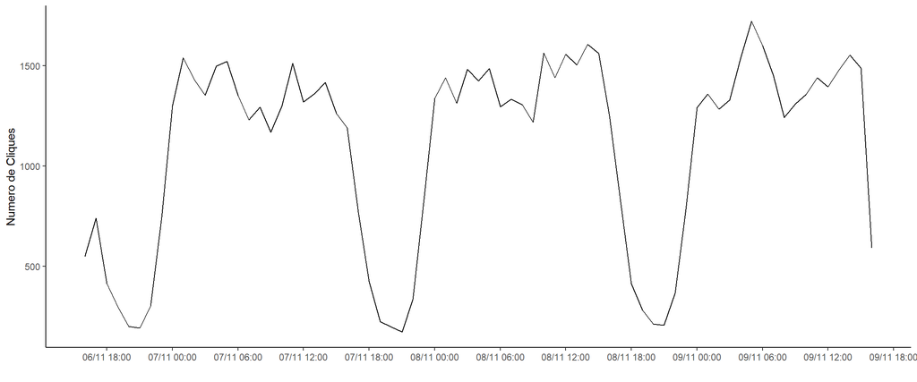

```r
# Tranformando a variavel click_time em POSIXct
data_treino$Anomes <- as.POSIXct(data_treino$click_time, format="%H:%M:%S")

#Arredondando os valores para a hora mais próxima
data_treino$Anomes4 <- fifelse(minute(data_treino$Anomes) >= 30,
                              ceiling_date(data_treino$Anomes, 'hour'),
                              floor_date(data_treino$Anomes, 'hour'))

# Criando uma query para agrupar as quantidade de clicks por data

GrafData <- data_treino %>%
              group_by(Anomes4) %>%
              select(Anomes4) %>%
              summarise(Count = n())

#Criando o gráfico para analise temporal
par(mfrow =c(1,1))

ggplot(GrafData, aes(x = Anomes4, y = Count)) +
  geom_line() +
  scale_x_datetime(date_labels = "%d/%m %H:%M", date_breaks = '6 hour') +
  xlab('') +
  ylab('Numero de Cliques')+
  theme_classic()
```

Com essa análise gráfica, percebe-se um padrão durante os três dias, onde os picos de cliques ocorrem durante a partir da 00:00 e mantém-se até perto das 18:00 onde começa a cair cada vez mais esse número, o qual volta ao seu pico novamente as 00:00

Em última análise, iremos verificar a proporção entre os níveis de nossa variável preditora,s, o ideal seria um proporção 50/50 esses.

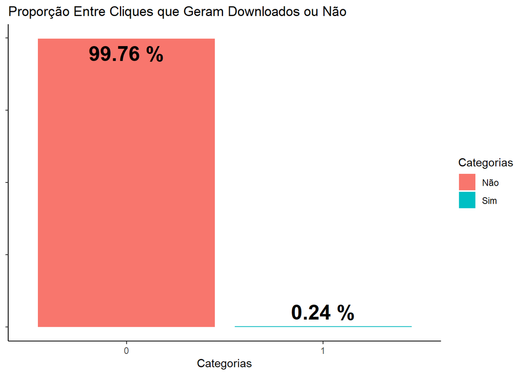

```r
ggplot(data_treino, aes(x = as.factor(is_attributed), fill = as.factor(is_attributed ) )) +
  geom_bar()+
  annotate('text',
           x = 1,
           y = nrow(data_treino[is_attributed == 0]) - 4000,
          label = paste(round(prop.table(table  (data_treino$is_attributed))[1]*100, digits = 2),'%',sep = ' '),
           size = 7,
           fontface = 2)+
  annotate('text',
           x = 2,
           y = nrow(data_treino[is_attributed == 1]) + 4000,
           label = paste(round(prop.table(table(data_treino$is_attributed))[2]*100, digits = 2),'%',sep = ' '),
           size = 7,
           fontface = 2) +
  scale_fill_hue(c = 40) +
  ggtitle('Proporção Entre Cliques que Geram Downloados ou Não') +
  xlab('Categorias')+
  labs(fill = 'Categorias')+
  scale_fill_discrete(name = "Categorias", labels = c("Não", "Sim"))+
  theme_classic() +
  theme(axis.title.y = element_blank(),
        axis.text.y = element_blank())
```

Isso nos traz a necessidade de futuramente realizar o balanceamento entre essas classes, para assim desenvolver modelos com melhor performance.

## Feature Selection

Nessa próxima etapa, criaremos um breve modelo utilizando `randomForest` para utilizar da função `varImpPlot`, assim obtendo um primeiro direcionamento para as melhores variáveis do modelo.

```r
data_treino$attributed_time <- NULL #Removendo a variavel attributed time pois ela não ser utilizada nas bases de teste
data_treino$Anomes <- NULL #Excluindo as variaveis criadas para a análise temporal
data_treino$Anomes4 <- NULL

# Criando o modelo
model <- randomForest(is_attributed ~.,
                      data= data_treino,
                      ntree = 15,
                      nodesize = 10,
                      importance = T)
```

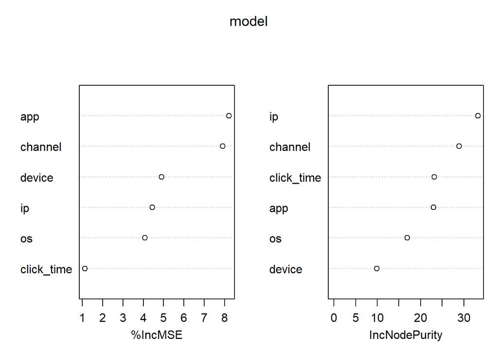

```r
#Plotando Variáveis mais representativas
varImpPlot(model)
```

É perceptível que os dois indicadores demonstram resultados bem diferentes em relação a escolha das variáveis mais importantes; devido isso e pelo fato de serem poucas variáveis, tomei como primeira decisão, utilizar todas como parâmetros para os modelos.

## Oversampling

Para solucionar a questão do desbalanceamento dos dados existem várias soluções, utilizaremos um método de oversampling para aumentar o número de observações que representam a classe minoritária, afim de manter o maior número de observações possível para em nossa base de dados.

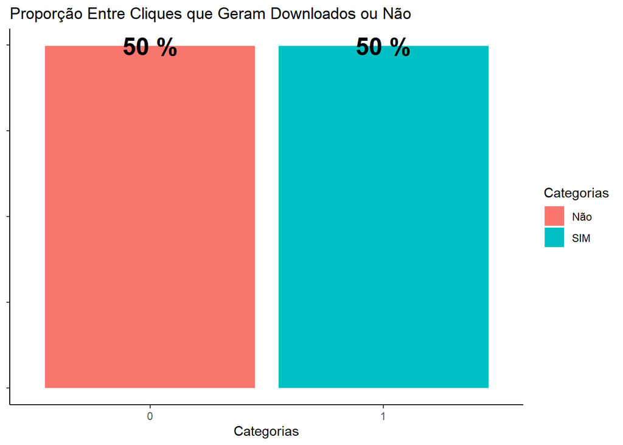

```r
#Comando para criar base balanceada, method = 'over' define o metodo de oversampling
 balanced_treino <-ovun.sample(is_attributed ~ .,
                              data = data_treino, method = "over"
                              )$data



ggplot(balanced_treino, aes(x = as.factor(is_attributed), fill = as.factor(is_attributed ) )) +
  geom_bar()+
  annotate('text',
           x = 1,
           y = nrow(balanced_treino[balanced_treino$is_attributed == 0,]) ,
           label = paste(round(prop.table(table(balanced_treino$is_attributed))[1]*100, digits = 2),'%',sep = ' '),
           size = 7,
           fontface = 2)+
  annotate('text',
           x = 2,
           y = nrow(balanced_treino[balanced_treino$is_attributed == 0,]) ,
           label = paste(round(prop.table(table(balanced_treino$is_attributed))[2]*100, digits = 2),'%',sep = ' '),
           size = 7,
           fontface = 2) +
  scale_fill_hue(c = 40) +
  ggtitle('Proporção Entre Cliques que Geram Downloados ou Não') +
  xlab('Categorias')+
  labs(fill = 'Categorias')+
  scale_fill_discrete(name = "Categorias", labels = c("Não", "SIM"))+
  theme_classic() +
  theme(axis.title.y = element_blank(),
        axis.text.y = element_blank())
```

Balanceando os dados de teste.

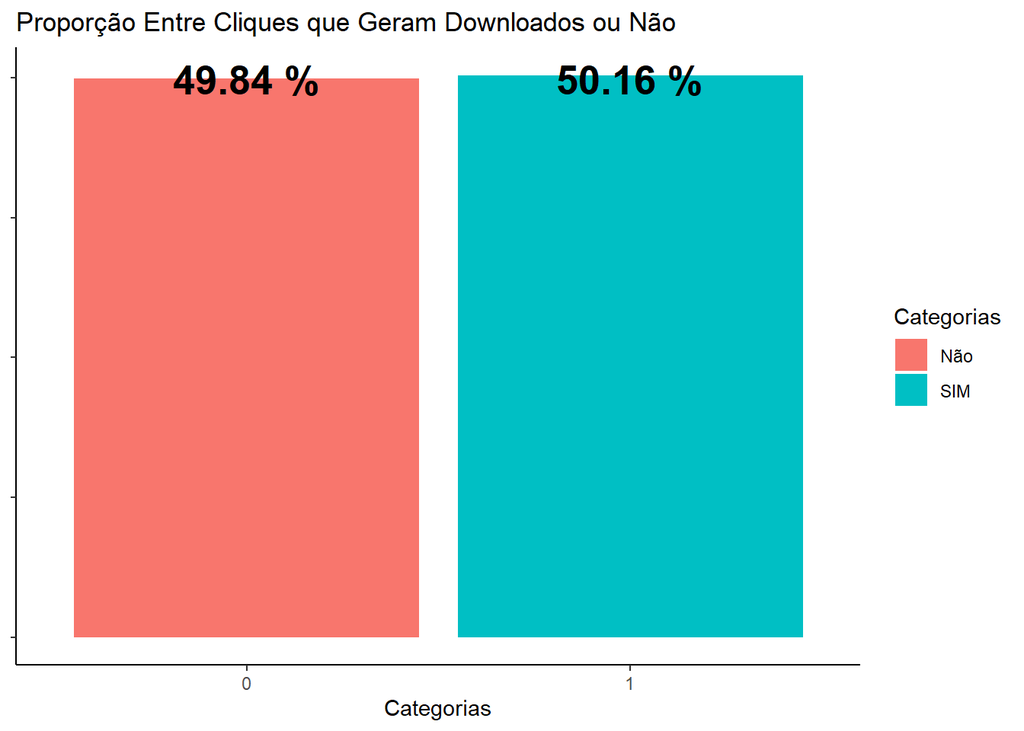

```r
data_teste$attributed_time <- NULL

balanced_teste <-ovun.sample(is_attributed ~ .,
                              data = data_teste, method = "over"
                              )$data


ggplot(balanced_teste, aes(x = as.factor(is_attributed), fill = as.factor(is_attributed ) )) +
  geom_bar()+
  annotate('text',
           x = 1,
           y = nrow(balanced_teste[balanced_teste$is_attributed == 0,]) ,
           label = paste(round(prop.table(table(balanced_teste$is_attributed))[1]*100, digits = 2),'%',sep = ' '),
           size = 7,
           fontface = 2)+
  annotate('text',
           x = 2,
           y = nrow(balanced_teste[balanced_teste$is_attributed == 0,]) ,
           label = paste(round(prop.table(table(balanced_teste$is_attributed))[2]*100, digits = 2),'%',sep = ' '),
           size = 7,
           fontface = 2) +
  scale_fill_hue(c = 40) +
  ggtitle('Proporção Entre Cliques que Geram Downloados ou Não') +
  xlab('Categorias')+
  labs(fill = 'Categorias')+
  scale_fill_discrete(name = "Categorias", labels = c("Não", "SIM"))+
  theme_classic() +
  theme(axis.title.y = element_blank(),
        axis.text.y = element_blank())
```

## Desenvolvimento dos Modelos

Com as features escolhidas e os dados balanceados, podemos prosseguir para a criação e avaliação dos modelos.

Serão testados os modelos de Regressão Logística e Random Forest, esses serão avaliados por sua acurácia e sua AUC (Area Under the Curve)

### Regressão logística binária

```r
#Criando o modelo de regressão logística

modeloRegLog <- glm(is_attributed ~.,
                    family = binomial(link = 'logit'),
                    data = balanced_treino)
summary(modeloRegLog)
```

```
##
## Call:
## glm(formula = is_attributed ~ ., family = binomial(link = "logit"),
##     data = balanced_treino)
##
## Deviance Residuals:
##     Min       1Q   Median       3Q      Max
## -8.4904  -0.7637  -0.0085   0.7490   2.2900
##
## Coefficients:
##               Estimate Std. Error z value Pr(>|z|)
## (Intercept)  3.467e+03  1.336e+02   25.95   <2e-16 ***
## ip           1.007e-05  7.172e-08  140.37   <2e-16 ***
## app          7.589e-02  5.893e-04  128.78   <2e-16 ***
## device       6.416e-04  6.134e-05   10.46   <2e-16 ***
## os          -9.739e-03  2.142e-04  -45.46   <2e-16 ***
## channel     -2.617e-03  5.264e-05  -49.71   <2e-16 ***
## click_time  -2.297e-06  8.847e-08  -25.96   <2e-16 ***
## ---
## Signif. codes:  0 '***' 0.001 '**' 0.01 '*' 0.05 '.' 0.1 ' ' 1
##
## (Dispersion parameter for binomial family taken to be 1)
##
##     Null deviance: 221273  on 159614  degrees of freedom
## Residual deviance: 154798  on 159608  degrees of freedom
## AIC: 154812
##
## Number of Fisher Scoring iterations: 6
```

Com o modelo pronto, podemos realizar as previsões e as avaliações do mesmo.

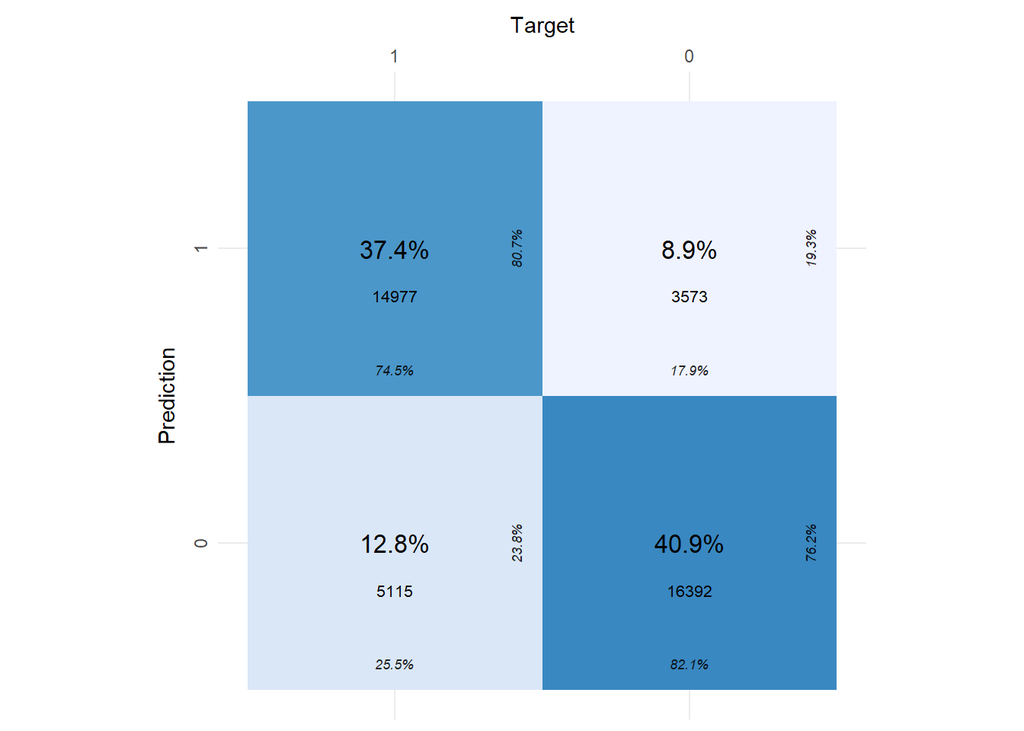

```r
#Realizando Previsões

predRegLog1 <- predict(modeloRegLog, balanced_teste[,-7], type = 'response')
predRegLog1 <- ifelse(predRegLog1 >0.5,1,0)
predRegLog2 <- predict(modeloRegLog, balanced_teste[,-7])


# Determinando Acuracia do Modelo Atraves de uma ConfusionMatrix


basic_table <- table(balanced_teste$is_attributed, predRegLog1, dnn = c('target','prediction'))
cfm <- as_tibble(basic_table)

plot_confusion_matrix(cfm,
                      target_col = 'target',
                      prediction_col = 'prediction',
                      counts_col = 'n')
```

```r
confusionMatrix(table(predRegLog1, balanced_teste$is_attributed))
```

```
## Confusion Matrix and Statistics
##
##
## predRegLog1     0     1
##           0 16392  5115
##           1  3573 14977
##
##                Accuracy : 0.7831
##                  95% CI : (0.779, 0.7871)
##     No Information Rate : 0.5016
##     P-Value [Acc > NIR] : < 2.2e-16
##
##                   Kappa : 0.5663
##
##  Mcnemar's Test P-Value : < 2.2e-16
##
##             Sensitivity : 0.8210
##             Specificity : 0.7454
##          Pos Pred Value : 0.7622
##          Neg Pred Value : 0.8074
##              Prevalence : 0.4984
##          Detection Rate : 0.4092
##    Detection Prevalence : 0.5369
##       Balanced Accuracy : 0.7832
##
##        'Positive' Class : 0
##
```

Através da Confusion Matrix observamos que a acurácia do modelo atingiu 78,3 % de acurácia, sendo o modelo um pouco mais preciso ao identificar os verdadeiros negativos acertando em 82,1% das vezes, contra 74,5% dos verdadeiros positivos.

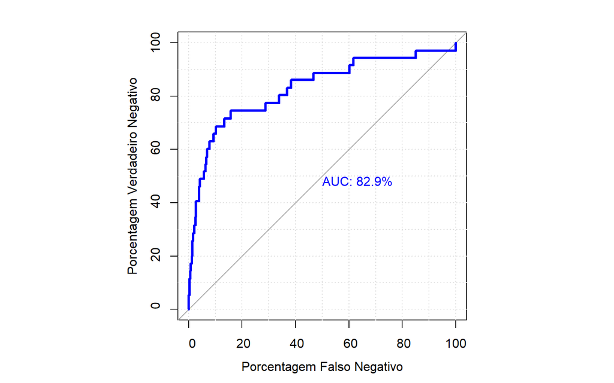

```r
#Gerando um Gráfico ROC com o Indicador de AUC

par(pty = 's')
roc_plot <- roc(balanced_teste$is_attributed, predRegLog2,
                levels = base::levels(as.factor(balanced_teste$is_attributed)),grid = TRUE,
                plot =TRUE, col = 'blue', lwd = 3, legacy.axes = TRUE, percent = TRUE,
                xlab = 'Porcentagem Falso Negativo', ylab = 'Porcentagem Verdadeiro Negativo',
                print.auc = TRUE)
```

### Modelo Random Forest

```r
balanced_treino$is_attributed <- as.factor(balanced_treino$is_attributed)

modeloRF <- randomForest(is_attributed~.,
                         data = balanced_treino,
                         ntree = 50,
                         nodesize = 10,
                         importance = TRUE)
modeloRF
```

```
##
## Call:
##  randomForest(formula = is_attributed ~ ., data = balanced_treino,      ntree = 50, nodesize = 10, importance = TRUE)
##                Type of random forest: classification
##                      Number of trees: 50
## No. of variables tried at each split: 2
##
##         OOB estimate of  error rate: 0.07%
## Confusion matrix:
##       0     1 class.error
## 0 79690   118 0.001478549
## 1     0 79807 0.000000000
```

Uma acurácia tão grande em um primeiro modelo, pode nos indicar o overfitting do mesmo, isso será verificado através da validação pelos dados de teste.

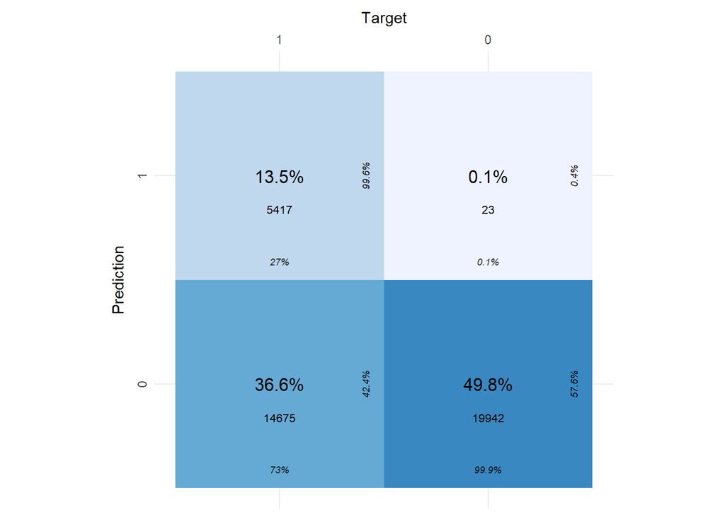

```r
#Previsao
predRF <- predict(modeloRF, balanced_teste[,-7])
predRF2 <-predict(modeloRF, balanced_teste[,-7],type = 'prob')[,2]

#Determinando acuracia

basic_table <- table(balanced_teste$is_attributed, predRF, dnn = c('target','prediction'))
cfm <- as_tibble(basic_table)

plot_confusion_matrix(cfm,
                      target_col = 'target',
                      prediction_col = 'prediction',
                      counts_col = 'n')
```

```r
confusionMatrix(table(predRF, balanced_teste$is_attributed))
```

```
## Confusion Matrix and Statistics
##
##
## predRF     0     1
##      0 19942 14675
##      1    23  5417
##
##                Accuracy : 0.6331
##                  95% CI : (0.6283, 0.6378)
##     No Information Rate : 0.5016
##     P-Value [Acc > NIR] : < 2.2e-16
##
##                   Kappa : 0.2678
##
##  Mcnemar's Test P-Value : < 2.2e-16
##
##             Sensitivity : 0.9988
##             Specificity : 0.2696
##          Pos Pred Value : 0.5761
##          Neg Pred Value : 0.9958
##              Prevalence : 0.4984
##          Detection Rate : 0.4978
##    Detection Prevalence : 0.8642
##       Balanced Accuracy : 0.6342
##
##        'Positive' Class : 0
##
```

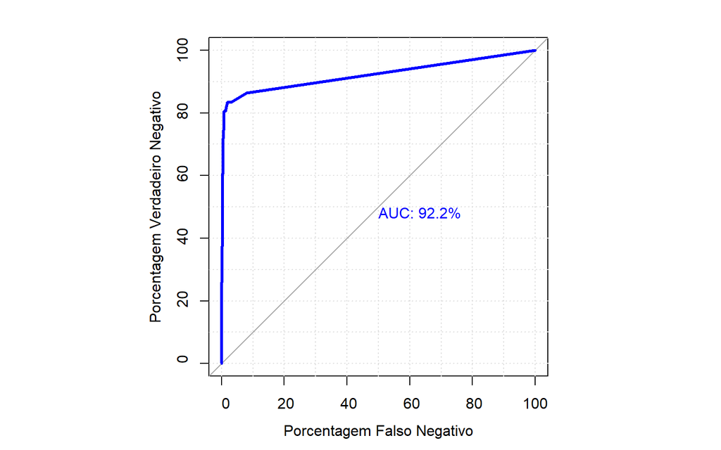

```r
par(pty ='s')
roc_plot2 <- roc(balanced_teste$is_attributed, predRF2,
                levels = base::levels(as.factor(balanced_teste$is_attributed)),grid = TRUE,
                plot =TRUE, col = 'blue', lwd = 3, legacy.axes = TRUE, percent = TRUE,
                xlab = 'Porcentagem Falso Negativo', ylab = 'Porcentagem Verdadeiro Negativo',
                print.auc = TRUE)
```

Com os dados de teste, identificamos que o modelo realmente conseguiu aprender muito bem a classificar casos da classe “0”, acertando em 99,8% das previsões, porém em casos da classe “1”, a acurácia cai para somente 27%.

O fato do modelo errar majoritariamente a classe anteriormente balanceada, abre a hipótese de que a técnica escolhida para o oversampling (ROSE) pode não ter sido a mais adequada.

### Balanceamento com Smote

Seguindo as evidências do processos anteriores, e enxergando o potencial no modelo Random Forest, será utilizado outro método de balanceamento de classes nos dados de treino.

Algumas leituras indicam que o método utilizado anteriormente (ROSE), muitas vezes cria amostras irreais quando comparado aos dados originais, podendo assim, prejudicar a performance do modelo. Em contra partida, a técnica de SMOTE utiliza do algoritmo KNN para criar dados sintéticos mais verossímeis.

Durante a realização desse novo processo, o algoritmo em R não aceitou a tipagem da variável `click_time` (POSIXct), devido isso foi realizado um processo de engenharia de atributos, onde essa variável foi dividida em outras três de formato **integer**, um referente ao dia, outro a hora e outro ao minuto da data original.

```r
data_treino$is_attributed <- as.factor(data_treino$is_attributed)
data_treino$dia <- day(data_treino$click_time)
data_treino$hora <- hour(data_treino$click_time)
data_treino$min <- minute(data_treino$click_time)
data_treino$click_time <- NULL


smote_treino <- SMOTE(is_attributed~., data_treino,
                      perc.over = 100,perc.under = 200,
                      k = 5, learner = NULL)



table(smote_treino$is_attributed)
```

```
##
##   0   1
## 384 384
```

Vale ressaltar que esse método reduz o tamanho da amostra fornecida; aumentando o número de observações da classe minoritária e cortando observações da classe majoritária.

### Random Forest V2

Com os novos dados de treino, irá ser gerado um modelo Random Forest igual ao anterior (salvo a mudança no balanceamento e nos atributos).

```r
modeloRF.2 <- randomForest(is_attributed~.,
                         data = smote_treino,
                         ntree = 50,
                         nodesize = 10,
                         importance = TRUE)

modeloRF.2
```

```
##
## Call:
##  randomForest(formula = is_attributed ~ ., data = smote_treino,      ntree = 50, nodesize = 10, importance = TRUE)
##                Type of random forest: classification
##                      Number of trees: 50
## No. of variables tried at each split: 2
##
##         OOB estimate of  error rate: 8.2%
## Confusion matrix:
##     0   1 class.error
## 0 358  26  0.06770833
## 1  37 347  0.09635417
```

Essa segunda versão apresenta uma ótima taxa de acerto, com alguns erros igualmente distribuídos entre as classes, parece não haver overfitting ou algum outro problema relacionado ao balanceamento de classes.

Para testar esse modelo, será usado os mesmos dados de teste utilizados anteriormente -o mesmo processo de engenharia de atributos utilizada nos novos dados de treino será feita nos de teste.

```r
balanced_teste$is_attributed <- as.factor(balanced_teste$is_attributed)
balanced_teste$dia <- day(balanced_teste$click_time)
balanced_teste$hora <- hour(balanced_teste$click_time)
balanced_teste$min <- minute(balanced_teste$click_time)
balanced_teste$click_time <- NULL
```

Realizando as previsões.

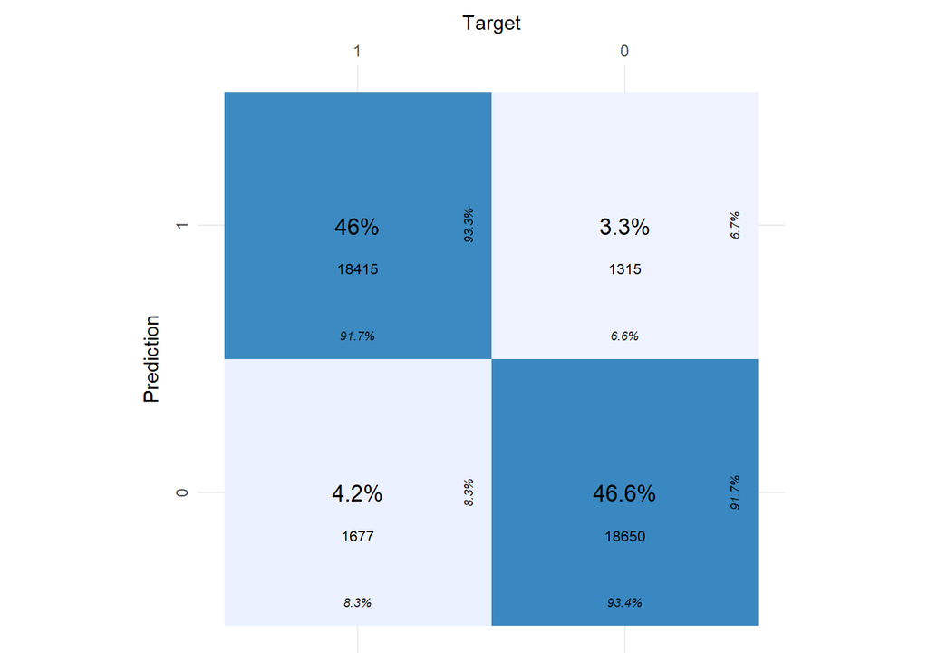

```r
#Previsao

predRF.2 <- predict(modeloRF.2, balanced_teste[,-6])
predRF2.2 <-predict(modeloRF.2, balanced_teste[,-6],type = 'prob')[,2]



#Determinando acuracia

basic_table <- table(balanced_teste$is_attributed, predRF.2, dnn = c('target','prediction'))
cfm <- as_tibble(basic_table)

plot_confusion_matrix(cfm,
                      target_col = 'target',
                      prediction_col = 'prediction',
                      counts_col = 'n')
```

```r
confusionMatrix(table(predRF.2, balanced_teste$is_attributed))
```

```
## Confusion Matrix and Statistics
##
##
## predRF.2     0     1
##        0 18650  1677
##        1  1315 18415
##
##                Accuracy : 0.9253
##                  95% CI : (0.9227, 0.9279)
##     No Information Rate : 0.5016
##     P-Value [Acc > NIR] : < 2.2e-16
##
##                   Kappa : 0.8506
##
##  Mcnemar's Test P-Value : 4.119e-11
##
##             Sensitivity : 0.9341
##             Specificity : 0.9165
##          Pos Pred Value : 0.9175
##          Neg Pred Value : 0.9334
##              Prevalence : 0.4984
##          Detection Rate : 0.4656
##    Detection Prevalence : 0.5075
##       Balanced Accuracy : 0.9253
##
##        'Positive' Class : 0
##
```

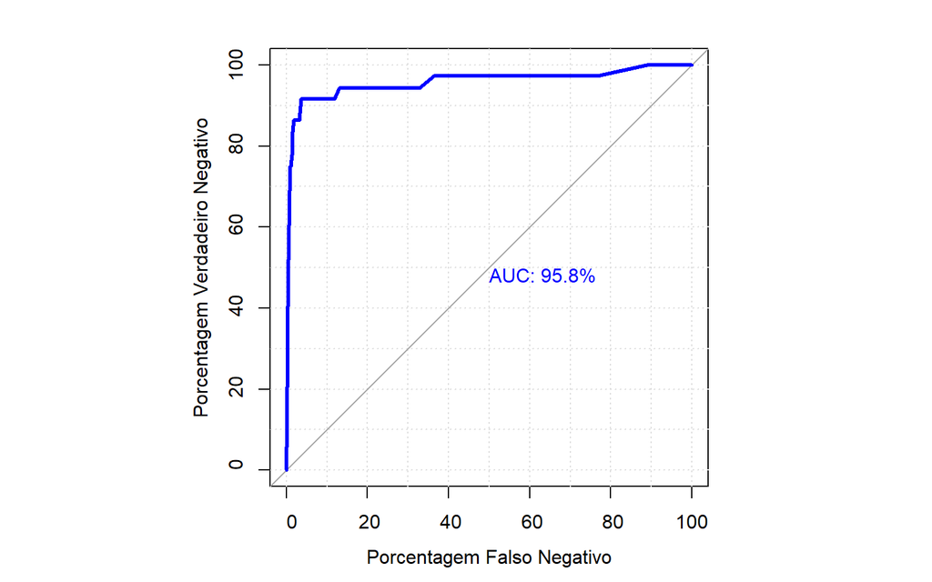

```r
par(pty ='s')
roc_plot2.2 <- roc(balanced_teste$is_attributed, predRF2.2,
                levels = base::levels(as.factor(balanced_teste$is_attributed)),grid = TRUE,
                plot =TRUE, col = 'blue', lwd = 3, legacy.axes = TRUE, percent = TRUE,
                xlab = 'Porcentagem Falso Negativo', ylab = 'Porcentagem Verdadeiro Negativo',
                print.auc = TRUE)
```

Essa segunda versão do modelo apresenta um acurácia de 92,5 %, uma taxa de 93,4% de true negatives e 91,7% de true positives, além de uma AUC de 95,8%, números esses extremamente satisfatórios para o objetivo desse modelo.

Vale ressaltar que todo esse desenvolvimento foi realizado em cima de uma pequena amostra oferecida de todos os dados, caso houvesse poder computacional para trabalhar com todos os dados disponíveis, e realizar processos como de Cross-Validation, a acurácia do modelo poderia ser ainda mais precisa.